# Water and Economy Xiaojing Ni - Water quality time series analysis — a time series case study of Toledo Ohio, U.S.

## Background

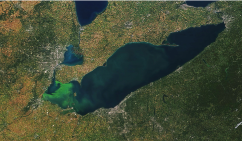

Figure 1: Lake Erie algae bloom outbreaks

Lake Erie’s harmful algae blooms (HABs, Figure 1) have been an annual threat to surrounding communities and businesses who worry about whether algae will: 1) pollute their drinking water; 2) harm the region’s vital tourism economy; and 3) prevent residents and visitors from recreational opportunities such as boating, swimming, and visiting shorelines. In fact, the city of Toledo Ohio, US (Figure 2) had to shut down their drinking water supply due to HABs detected in Lake Erie in the summer of 2014, which affected more than a half million residents in Toledo.

Sediment with the nutrients attached to it is considered as one of the major contributor to HABs. When sediment is eroded from the surrounding landscape and enters a stream, it can carry with it attached nutrients that can contribute to excess nutrients in the water. This can lead to algal blooms, reduced dissolved oxygen levels, and other negative impacts on aquatic ecosystems.

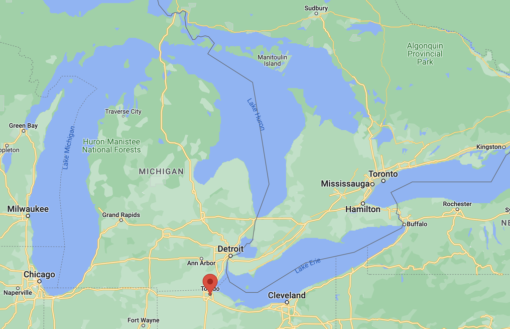

Figure 2: Toledo, Ohio, U.S.

## Initial questions and incentives

Initially, I want to answer following questions:

1. What are the stream water quantity and quality distribution, including streamflow, sediment, phosphorus, near the outlet from Toledo, Ohio, U.S. to Lake Erie?
2. Have the stream water quantity and quality changed overtime?
3. If the stream water quantity and quality changed overtime, how? Any particular events?
4. How about the economy, representing by population, house price, agriculture and recreation output distributions, in Toledo Ohio, US overtime?
5. Have the economy indicators have similar or various trends?
6. How and why their trends similar or different?
7. Any similarity or difference among water quality indicators and economy indicators?
8. How and why of the question 7?
9. Can we predict water quality with time series model with factors including climate and economic features?
10. Can we do the other way around of question 9?

With more and more research on this topic, I found that due to the different periodicity of economy and water quality evaluation, i.e. economy normally is reported quarterly, while water quality index are measured monthly, it is hard to incorporate these two time series data, especially the water quality data are usually limited to less than 10 years. My focus has shifted to water quality time series analysis, with a stand along analysis on the “[Financial time series model](https://xni.georgetown.domains/timeseries560/financial.html)”.

## Objective

The main objective of this study is to investigate the water quality index, such as stream flow discharge, turbidity, and sediment, as time series data. More specifically shown in Figure 3, various time series models were used to simulate stream flow discharge, i.e. ARMA, ARIMA, SARIMA, VAR, turbidity, i.e. SARIMAX, and sediment, i.e. VAR. In addition, the climate data, such as precipitation and temperature were also used to predict the water quality index. In the “[Financial time series model](https://xni.georgetown.domains/timeseries560/financial.html)” session, GARCH model are used to analyze water treatment company, Xylem, stock prices.

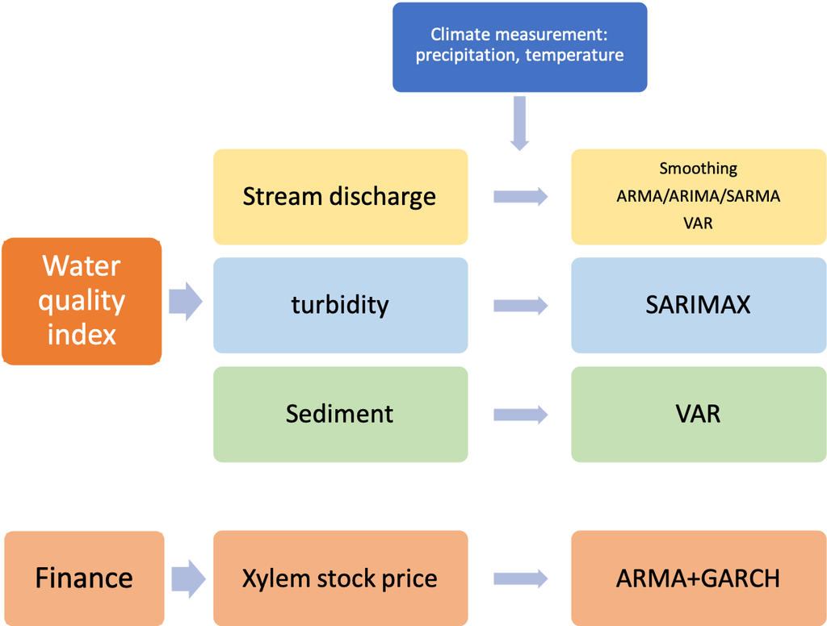

Figure 3: Big picture